# Bike Rides Trends and Bikers Types Nature for Ford GoBike System Febraury, 2019)

## by (Mina Habib)

## Investigation Overview

In this presentation we will investigat how user types have their own atitude of using Gobike system, and how speed and what distance the go for by thier categories of age & gendars

## Dataset Overview

Ford GoBike System Dateset is a dateset that contains Bike trips service for public use. Variables including, trip duration, start time and end time with date, start station and end station names, start and end coordinates, customer type, year of birth and gender.

## Ford GoBike Usage by Feb Days Hours, Weekdays & Average Distance For

## Subscribers & Customers

February Days Hours Gobike usage is showing us that most people who uses GoBike System as Subscriber are using it for their daily commutes "7am to 9am","4pm to 6pm" & less distance, but on the other hand the Customer slightly have increse in same hours which hasn't much effect & when we see Weekends Days that have less Bike rides fo Subscribers but almost the same for Customers so we can assume that Customers bike rides are for more distance so it could be for having fun or just escape bad traffics.

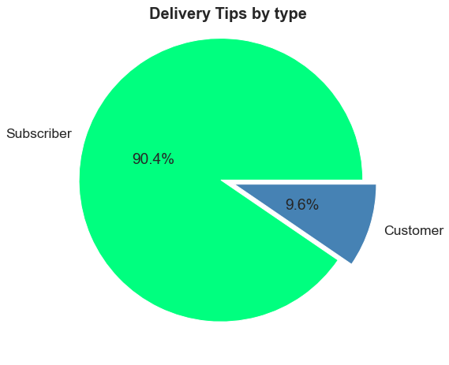

```python
# Pie chart for User Type illustration
sb.set(font_scale=1.6)
pie, ax = plt.subplots(figsize=[11.69, 8.27])
colors2 = ['springgreen', 'steelblue']
labels = df.user_type.value_counts().keys()
plt.pie(x=df.user_type.value_counts(), autopct="%.1f%%", explode=[0.05]*2, labels=labels, pctdistance=0.5, colors = colors2)
plt.title("Delivery Tips by type", fontsize=20, y=0.95, fontweight='bold');
```

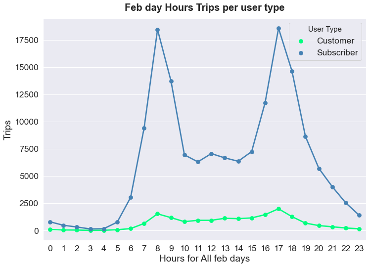

```python
# Hourly bike rides for february by user type
hours_per_user_count = df.groupby(["start_time_hour", "user_type"]).size().reset_index()
plt.figure(figsize=(11.69, 8.27))
palette2 = {'Subscriber': 'steelblue', 'Customer': 'springgreen'}
axis = sb.pointplot(x='start_time_hour', y=0 , hue='user_type', palette=palette2, scale=1, data = hours_per_user_count)
plt.title('Feb day Hours Trips per user type', fontsize=20, y=1.02, fontweight='bold')
plt.xlabel('Hours for All feb days')
plt.ylabel('Trips')
leg = axis.legend()
leg.set_title('User Type',prop={'size':15})
axis = plt.gca();
```

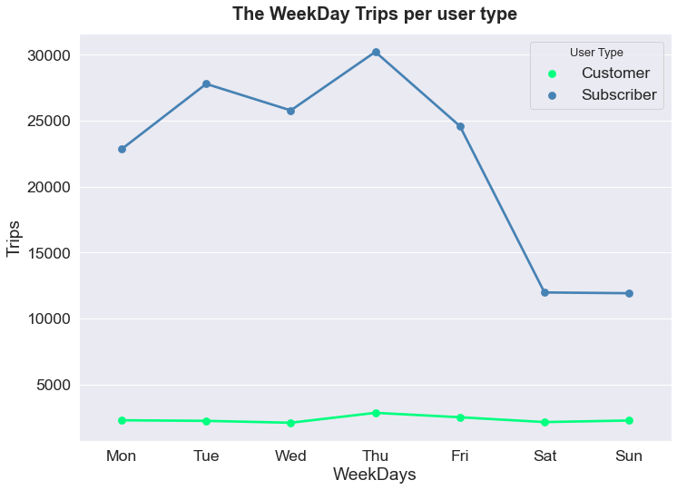

```python
# weekdays bike rides for february by user type
weekday_per_user_count = df.groupby(["start_time_weekday", "user_type"]).size().reset_index()
plt.figure(figsize=(11.69, 8.27))
weekdays = ['Mon','Tue','Wed','Thu','Fri', 'Sat', 'Sun']
axis = sb.pointplot(x='start_time_weekday', y=0 , hue='user_type', palette=palette2, scale=1, data = weekday_per_user_count, order=weekdays)
plt.title('The WeekDay Trips per user type', fontsize=20, y=1.02, fontweight='bold')
plt.xlabel('WeekDays')
plt.ylabel('Trips')
leg = axis.legend()
leg.set_title('User Type',prop={'size':13})
axis = plt.gca();
```

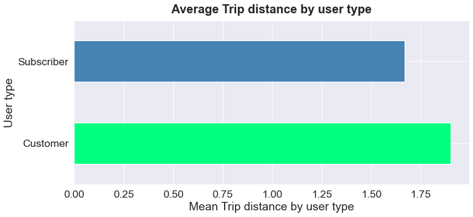

```python
# Average Trip distance by user type
plt.figure(figsize=(11.69, 5))
axis = df.groupby('user_type')['dist_km'].mean().plot(kind='barh', color=colors2)
axis.set_title('Average Trip distance by user type', fontsize=20, y=1.02, fontweight='bold')
axis.set_ylabel('User type')
axis.set_xlabel('Mean Trip distance by user type');
```

## Ford GoBike Usage Comparison For

## 17 - 26 & 26 - 38 & 38 - 50 & 50 - 60

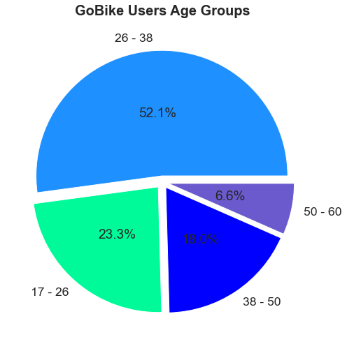

```python
# Pie Ploting Users due to age
colors = ['dodgerblue', 'mediumspringgreen', 'blue' , 'slateblue']
pie, ax = plt.subplots(figsize=[11.69, 8.27])
labels = df.age_groups.value_counts().keys()
plt.pie(x=df.age_groups.value_counts(), autopct="%.1f%%", explode=[0.05]*4, labels=labels, pctdistance=0.5, colors=colors)
plt.title("GoBike Users Age Groups", fontsize=20, y=1.02, fontweight='bold');
```

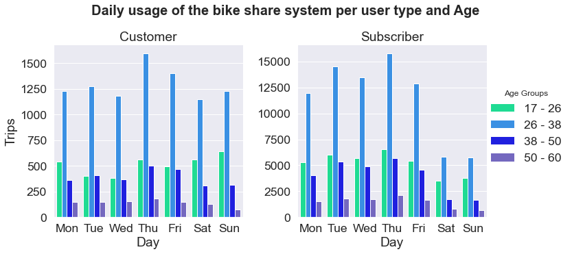

```python
# Daily usege of the bike sharing system per user type and gender
plt.figure(figsize=(11.69, 8.27))
age_order = ['17 - 26', '26 - 38', '38 - 50', '50 - 60']
palette = {'17 - 26': 'mediumspringgreen', '26 - 38': 'dodgerblue', '38 - 50': 'blue', '50 - 60': 'slateblue'}
weekdays = ['Mon','Tue','Wed','Thu','Fri', 'Sat', 'Sun']
g = sb.catplot(data=df, x='start_time_weekday', col="user_type", hue="age_groups",hue_order=age_order, kind='count', sharey = False, palette=palette, order=weekdays)
g.set_axis_labels("Day", "Trips")
g._legend.set_title('Age Groups')
g.set_titles("{col_name}")
g.fig.suptitle('Daily usage of the bike share system per user type and Age', y=1.05, fontsize=20, fontweight='bold');
```

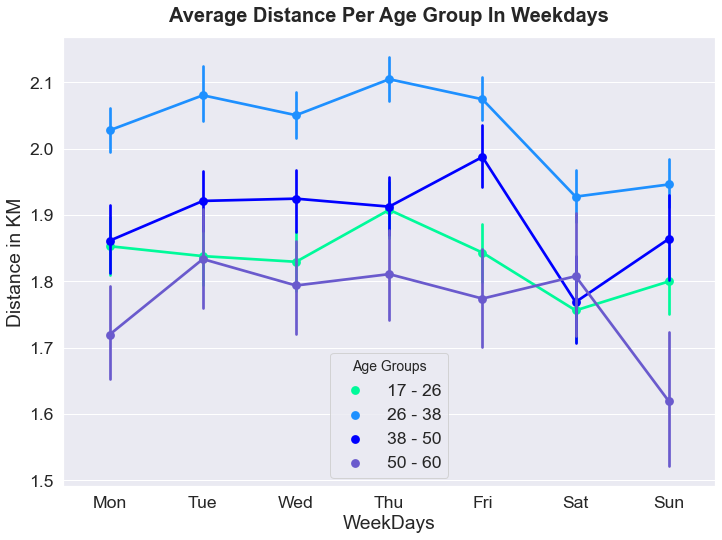

```python
weekday_per_user_count = df.groupby(['start_time_weekday', 'age_groups', 'dist_km']).size().reset_index()
plt.figure(figsize=(11.69, 8.27))
axis = sb.pointplot(x='start_time_weekday', y='dist_km' , hue='age_groups', palette=palette, scale=1, data = weekday_per_user_count, order=weekdays, legend_out=False)
plt.title('Average Distance Per Age Group In Weekdays', fontsize=20, y=1.02, fontweight='bold')
plt.xlabel('WeekDays')
plt.ylabel('Distance in KM')
leg = axis.legend()
leg.set_title('Age Groups',prop={'size':14})
axis = plt.gca();
```

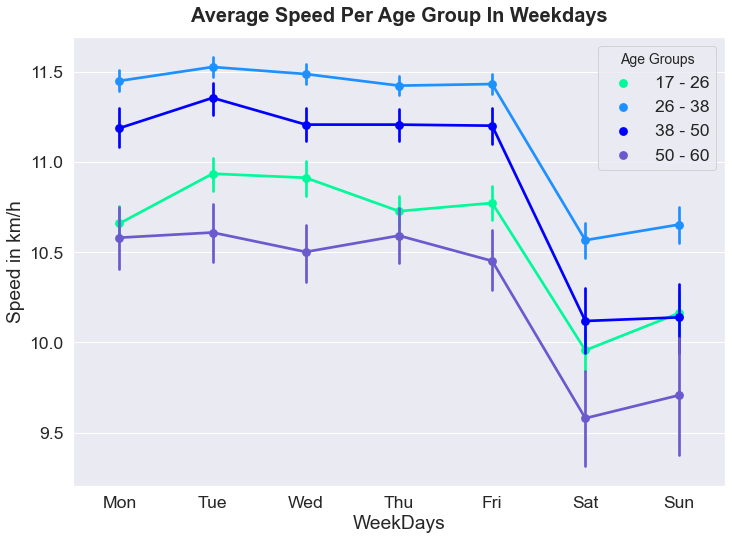

```python
weekday_per_user_count = df.groupby(['start_time_weekday', 'age_groups', 'speed_kmh']).size().reset_index()
plt.figure(figsize=(11.69, 8.27))
axis = sb.pointplot(x='start_time_weekday', y='speed_kmh' , hue='age_groups', palette=palette, scale=1, data = weekday_per_user_count, order=weekdays, legend_out=False)
plt.title('Average Speed Per Age Group In Weekdays', fontsize=20, y=1.02, fontweight='bold')
plt.xlabel('WeekDays')
plt.ylabel('Speed in km/h')
leg = axis.legend()
leg.set_title('Age Groups',prop={'size':14})
axis = plt.gca();
```

## Ford GoBike Usage Comparison For

## Females & Males & Others

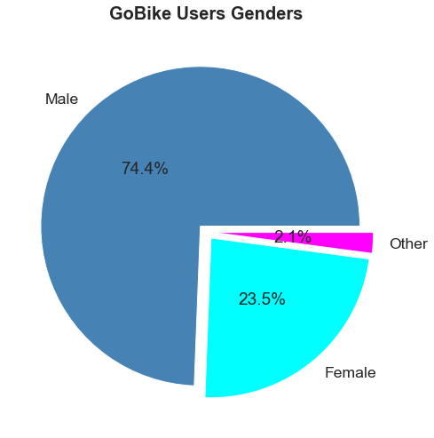

```python
# Pie Ploting Users due to age groups
colors = ['steelblue', 'aqua', 'fuchsia']
pie, ax = plt.subplots(figsize=[11.69, 8.27])
labels = df.member_gender.value_counts().keys()
plt.pie(x=df.member_gender.value_counts(), autopct="%.1f%%", explode=[0.05]*3, labels=labels, pctdistance=0.5, colors=colors)
plt.title("GoBike Users Genders", fontsize=20, y=1.02, fontweight='bold');
```

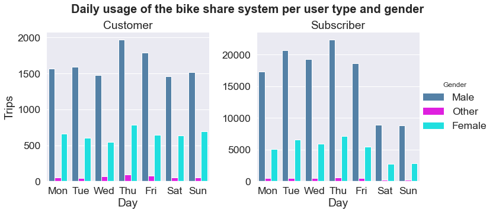

```python
# Daily usege of the bike sharing system per user type and gender
sb.set(font_scale=1.6)
palette1 = {'Female': 'aqua', 'Male': 'steelblue', 'Other': 'fuchsia'}
g = sb.catplot(data=df, x='start_time_weekday', col="user_type", hue="member_gender", kind='count',palette= palette1, order=weekdays, sharey = False)
g.set_axis_labels("Day", "Trips")
g._legend.set_title('Gender')
g.set_titles("{col_name}")
g.fig.suptitle('Daily usage of the bike share system per user type and gender', y=1.02, fontsize=20, fontweight='bold');
```

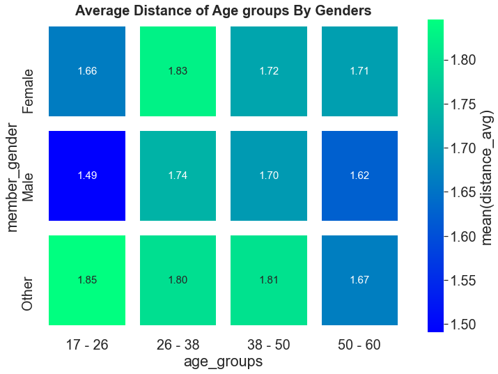

```python
#heatmaping Distance by age groups and Genders
sb.set(font_scale=1.8)
fig, ax = plt.subplots(figsize=(11.69, 8.27))
age_user_speed = df.groupby(['age_groups', 'member_gender']).mean()['dist_km']
age_user_speed = age_user_speed.reset_index(name = 'distance_avg')
age_user_speed = age_user_speed.pivot(index = "member_gender", columns = 'age_groups', values = 'distance_avg')
sb.heatmap(age_user_speed, annot = True, fmt = '.2f',cmap="winter", ax=ax, linewidths=20, cbar_kws = {'label' : 'mean(distance_avg)'}, annot_kws={"fontsize":15})
ax.set_title('Average Distance of Age groups By Genders', y=1.02, fontsize=20, fontweight='bold');
```

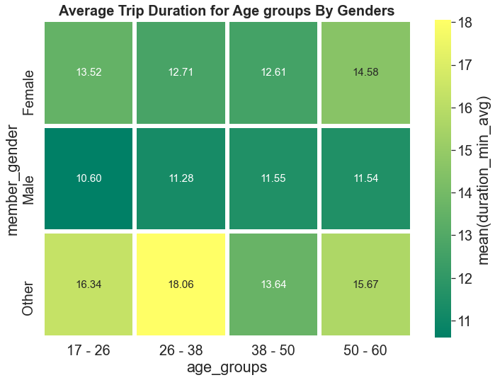

```python
#heatmaping Trip Duration by age groups and Genders
fig, ax = plt.subplots(figsize=(11.69, 8.27))
age_user_speed = df.groupby(['age_groups', 'member_gender']).mean()['duration_min']
age_user_speed = age_user_speed.reset_index(name = 'duration_min_avg')
age_user_speed = age_user_speed.pivot(index = "member_gender", columns = 'age_groups', values = 'duration_min_avg')
sb.heatmap(age_user_speed, annot = True, fmt = '.2f',cmap="summer", ax=ax, linewidths=5, cbar_kws = {'label' : 'mean(duration_min_avg)'}, annot_kws={"fontsize":15})
ax.set_title('Average Trip Duration for Age groups By Genders', y=1.02, fontsize=20, fontweight='bold');
```

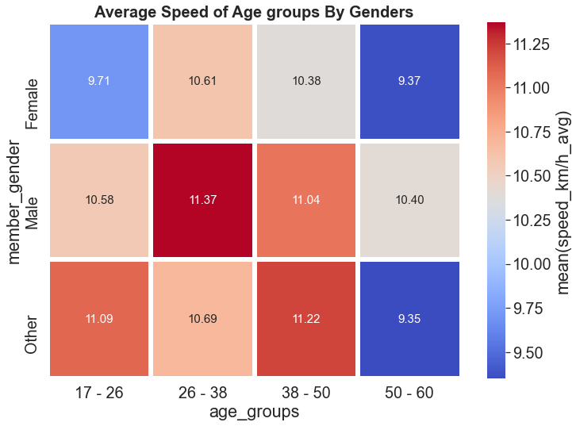

```python
#heatmaping Speed "Km/h" by age groups and Genders
fig, ax = plt.subplots(figsize=(11.69, 8.27))
age_user_speed = df.groupby(['age_groups', 'member_gender']).mean()['speed_kmh']
age_user_speed = age_user_speed.reset_index(name = 'speed_km/h_avg')
age_user_speed = age_user_speed.pivot(index = "member_gender", columns = 'age_groups', values = 'speed_km/h_avg')
sb.heatmap(age_user_speed, annot = True, fmt = '.2f',cmap="coolwarm", ax=ax, linewidths=5, cbar_kws = {'label' : 'mean(speed_km/h_avg)'}, annot_kws={"fontsize":15})
ax.set_title('Average Speed of Age groups By Genders', y=1.02, fontsize=20, fontweight='bold');
```